# Introduction to Data Science: Semester Project (Phase 1 — Midterm)

Kazi Fahad Mahin, Wakar Alvee ,TANJIM KHAN NABIL

2026-07-22

# Package Installation and Loading

All required packages are installed dynamically so this document runs on any machine without any manual setup.

```r
if (!require("tidyverse"))   install.packages("tidyverse")
if (!require("skimr"))       install.packages("skimr")
if (!require("caret"))       install.packages("caret")
if (!require("moments"))     install.packages("moments")
if (!require("ggcorrplot"))  install.packages("ggcorrplot")
if (!require("knitr"))       install.packages("knitr")
if (!require("kableExtra"))  install.packages("kableExtra")

library(tidyverse)
library(skimr)
library(caret)
library(moments)
library(ggcorrplot)
library(knitr)
library(kableExtra)
```

# Section 1 — Problem Framing

## 1.1 Domain Context and Dataset Background

Mental health among students has emerged as one of the most critical public health challenges of the 21st century. Depression is a leading cause of disability worldwide and is particularly prevalent in the student population, where it significantly affects academic performance, social engagement, physical health, and overall quality of life. According to the World Health Organisation (WHO), depression affects more than 300 million people globally, with onset most commonly occurring during adolescence and early adulthood — precisely the years that overlap with higher education.

Multiple intersecting factors contribute to student depression: high academic pressure, financial burdens, disrupted sleep patterns, poor dietary habits, limited social support, and a family history of mental illness all play important roles. Despite the scale of the problem, depression in students remains widely underdiagnosed and under-treated due to persistent stigma and limited access to mental health services in educational institutions.

This project utilises the **Student Depression Dataset** (Kaggle, 2024 — published by *hopesb*), titled *“Analyzing Mental Health Trends and Predictors Among Students.”* The dataset captures self-reported mental health, lifestyle, and academic attributes from **27,901 students** across 52 cities in India. It contains **18 variables** spanning four key domains:

- **Demographic Variables:** `id`, `Gender`, `Age`, `City`
- **Academic & Professional Variables:** `Profession`, `Academic Pressure`, `Work Pressure`, `CGPA`, `Study Satisfaction`, `Job Satisfaction`, `Degree`
- **Lifestyle Variables:** `Sleep Duration`, `Dietary Habits`, `Work/Study Hours`
- **Mental Health & Stress Variables:** `Financial Stress`, `Have you ever had suicidal thoughts ?`, `Family History of Mental Illness`
- **Target Variable:** `Depression` (binary: 1 = Depressed, 0 = Not Depressed)

The dataset contains realistic data quality challenges — only 3 missing values (in `Financial Stress`), an ordinal categorical variable (`Sleep Duration`) stored as multi-level text requiring encoding, `Work Pressure` and `Job Satisfaction` columns with near-zero variance (since 99.9% of respondents are students), and potential data entry errors in the `City` column — making it a rich and authentic candidate for a complete data science pipeline.

## 1.2 Research Questions

Three specific, testable analytical questions guide this project:

**RQ1 — Academic Pressure and Financial Stress as Drivers of Depression:** > Do students with high Academic Pressure (score ≥ 4 on the 0–5 scale) and high Financial > Stress (score ≥ 4 on the 1–5 scale) exhibit a significantly higher proportion of > depression (Depression = 1) compared to students with lower levels of both stressors?

**RQ2 — Sleep Duration and Depression Status:** > Do students who sleep fewer than 5 hours per night show a significantly higher rate of > depression compared to students who sleep 7–8 hours, after controlling for Academic > Pressure?

**RQ3 — Predictive Modelling of Student Depression:** > Can a supervised binary classification model, trained on academic, lifestyle, and > demographic features, predict student depression status with an AUC-ROC score > exceeding 0.80 on a held-out test set?

## 1.3 Success Criteria and Evaluation Metrics

Since `Depression` is a **binary classification target** and the dataset shows a moderate class imbalance (58.5% depressed vs. 41.5% not depressed), raw accuracy can be misleading. The following success criteria are defined:

Table 1.1: Project Success Criteria and Evaluation Metrics

| Evaluation Metric | Target Threshold | Justification |
| --- | --- | --- |
| Classification Accuracy | >= 80% on held-out test set | Standard baseline for binary classification tasks |
| AUC-ROC Score | >= 0.80 | Preferred metric under class imbalance; measures discriminative ability across all thresholds |
| Recall (Sensitivity) — Depression = 1 | >= 0.75 (minimise missed depressed students) | In a mental health context, failing to identify a depressed student (false negative) carries a higher real-world cost than a false positive |
| F1-Score | >= 0.75 | Harmonic mean of precision and recall — balances both error types for the positive class |
| Precision | >= 0.70 | Ensures the model does not produce excessive false positive flags for depressed status |

**Recall** and **AUC-ROC** are prioritised because early identification of at-risk students is the primary applied goal. Failing to identify a depressed student (false negative) has a substantially higher cost than incorrectly flagging a non-depressed student (false positive).

## 1.4 Dataset Justification

Table 1.2: Dataset Selection Requirements Checklist

Project Requirement

Status

Evidence from Actual Data

Minimum 500 rows

✔ Met

27,901 student records — 55× the 500-row minimum

Minimum 8 variables

✔ Met

18 variables — exceeds the 8-variable minimum

Clearly definable target variable

✔ Met

`Depression` (binary: 1 = Depressed, 0 = Not Depressed) — 16,336 positive cases (58.5%) vs. 11,565 negative cases (41.5%) — well-suited for classification

Mix of numeric and categorical features

✔ Met

Numeric: Age, CGPA, Academic Pressure, Work Pressure, Study Satisfaction, Job Satisfaction, Work/Study Hours, Financial Stress (8 numeric). Categorical: Gender, City, Profession, Sleep Duration, Dietary Habits, Degree, Suicidal Thoughts, Family History of Mental Illness, Depression (10 categorical)

Contains real messiness

✔ Met

1. Financial Stress has 3 missing values requiring imputation. (2) Sleep Duration is stored as ordinal text (‘Less than 5 hours’, ‘5-6 hours’, ‘7-8 hours’, ‘More than 8 hours’, ‘Others’) needing numeric encoding. (3) Work Pressure and Job Satisfaction are near-zero for all 27,870 student respondents — near-zero variance columns requiring evaluation for removal. (4) City column contains apparent data entry errors (e.g., ‘M.Tech’, ‘3.0’, ‘Saanvi’ appear as city names). (5) Dietary Habits and Sleep Duration each have a small ‘Others’ category (12 and 18 records respectively) requiring treatment

Publicly accessible via direct URL

✔ Met

Dataset downloaded from Kaggle and uploaded to a public GitHub repository for direct URL loading — no authentication required (see Section 2.1)

The Student Depression Dataset is also pedagogically ideal: it covers the full data science lifecycle — from raw inspection and categorical encoding through EDA, feature engineering, modelling, and evaluation — while addressing a socially significant real-world problem that is directly relevant to the academic context of this course.

# Section 2 — Data Acquisition & Initial Inspection

## 2.1 Loading the Dataset

The original dataset is published on Kaggle: `https://www.kaggle.com/datasets/hopesb/student-depression-dataset`

```r
library(readr)

url <- "https://drive.google.com/uc?export=download&id=1tbt8lECwqnPcanJXmTf1gC_fw7gjxnBQ"

depression <- read_csv(url, show_col_types = FALSE)
```

## 2.2 Dataset Dimensions

```r
cat("Number of rows (students / observations) :", nrow(depression), "\n")
```

```
## Number of rows (students / observations) : 27901
```

```r
cat("Number of columns (variables)             :", ncol(depression), "\n")
```

```
## Number of columns (variables)             : 18
```

```r
cat("Full dimensions                           :", paste(dim(depression), collapse = " x "), "\n")
```

```
## Full dimensions                           : 27901 x 18
```

**Observation:** With 27,901 observations and 18 variables, the dataset is sufficiently large for robust statistical analysis and reliable machine learning model training and validation. The large sample size substantially reduces the risk of overfitting and allows for a meaningful 80/20 train-test split — yielding approximately 22,320 training records and 5,580 test records in Phase 2.

## 2.3 Variable Names and Data Types

```r
tibble(
  `#`             = seq_along(names(depression)),
  `Variable Name` = names(depression),
  `R Data Type`   = sapply(depression, class),
  `Role`          = c("Identifier", rep("Predictor", 16), "Target"),
  `Domain Type`   = c(
    "Unique integer ID — not a predictive feature; exclude from modelling",
    "Nominal categorical — Male (55.7%) / Female (44.3%)",
    "Numeric continuous — age in years; range: 18–59, mean: 25.82",
    "Nominal categorical — 52 unique cities (contains data entry errors to fix)",
    "Nominal categorical — 99.9% 'Student'; near-zero variance",
    "Ordinal numeric scale 0–5 — academic workload stress; mean: 3.14",
    "Ordinal numeric scale 0–5 — work-related stress; near-zero for students",
    "Numeric continuous — Indian 10-point GPA scale; range: 0–10, mean: 7.66",
    "Ordinal numeric scale 0–5 — satisfaction with studies; mean: 2.94",
    "Ordinal numeric scale 0–4 — satisfaction with job; near-zero for students",
    "Ordinal categorical text — 5 levels: 'Less than 5 hours','5-6 hours','7-8 hours','More than 8 hours','Others'",
    "Nominal categorical — 3 levels: 'Healthy','Moderate','Unhealthy' (+ 12 'Others')",
    "Nominal categorical — 28 unique degree types",
    "Binary categorical — Yes (63.3%) / No (36.7%): mental health risk factor",
    "Numeric continuous — daily work or study hours; range: 0–12, mean: 7.16",
    "Ordinal numeric scale 1–5 — financial burden; mean: 3.14; 3 missing values",
    "Binary categorical — No (51.6%) / Yes (48.4%): hereditary mental health risk",
    "Binary numeric TARGET — 1 = Depressed (58.5%) / 0 = Not Depressed (41.5%)"
  )
) %>%
  kable(caption = "Table 2.1: All 18 Variables — Names, Types, and Domain Interpretation") %>%
  kable_styling(bootstrap_options = c("striped", "hover", "condensed"),
                full_width = TRUE, font_size = 11) %>%
  column_spec(1, width = "3%") %>%
  column_spec(2, bold = TRUE, width = "18%") %>%
  column_spec(3, width = "10%") %>%
  column_spec(4, width = "8%") %>%
  column_spec(5, width = "61%")
```

Table 2.1: All 18 Variables — Names, Types, and Domain Interpretation

| # | Variable Name | R Data Type | Role | Domain Type |
| --- | --- | --- | --- | --- |
| 1 | id | numeric | Identifier | Unique integer ID — not a predictive feature; exclude from modelling |
| 2 | Gender | character | Predictor | Nominal categorical — Male (55.7%) / Female (44.3%) |
| 3 | Age | numeric | Predictor | Numeric continuous — age in years; range: 18–59, mean: 25.82 |
| 4 | City | character | Predictor | Nominal categorical — 52 unique cities (contains data entry errors to fix) |
| 5 | Profession | character | Predictor | Nominal categorical — 99.9% ‘Student’; near-zero variance |
| 6 | Academic Pressure | numeric | Predictor | Ordinal numeric scale 0–5 — academic workload stress; mean: 3.14 |
| 7 | Work Pressure | numeric | Predictor | Ordinal numeric scale 0–5 — work-related stress; near-zero for students |
| 8 | CGPA | numeric | Predictor | Numeric continuous — Indian 10-point GPA scale; range: 0–10, mean: 7.66 |
| 9 | Study Satisfaction | numeric | Predictor | Ordinal numeric scale 0–5 — satisfaction with studies; mean: 2.94 |
| 10 | Job Satisfaction | numeric | Predictor | Ordinal numeric scale 0–4 — satisfaction with job; near-zero for students |
| 11 | Sleep Duration | character | Predictor | Ordinal categorical text — 5 levels: ‘Less than 5 hours’,‘5-6 hours’,‘7-8 hours’,‘More than 8 hours’,‘Others’ |
| 12 | Dietary Habits | character | Predictor | Nominal categorical — 3 levels: ‘Healthy’,‘Moderate’,‘Unhealthy’ (+ 12 ‘Others’) |
| 13 | Degree | character | Predictor | Nominal categorical — 28 unique degree types |
| 14 | Have you ever had suicidal thoughts ? | character | Predictor | Binary categorical — Yes (63.3%) / No (36.7%): mental health risk factor |
| 15 | Work/Study Hours | numeric | Predictor | Numeric continuous — daily work or study hours; range: 0–12, mean: 7.16 |
| 16 | Financial Stress | numeric | Predictor | Ordinal numeric scale 1–5 — financial burden; mean: 3.14; 3 missing values |
| 17 | Family History of Mental Illness | character | Predictor | Binary categorical — No (51.6%) / Yes (48.4%): hereditary mental health risk |
| 18 | Depression | numeric | Target | Binary numeric TARGET — 1 = Depressed (58.5%) / 0 = Not Depressed (41.5%) |

1. **`Work Pressure` and `Job Satisfaction`** — both have a mean of approximately 0.00, because 99.9% of respondents are students with no active employment. These columns have near-zero variance and will likely be excluded during feature selection in Section 4.
2. **`Sleep Duration`** — stored as ordinal text, not a number. Must be encoded as an ordered numeric (1 = Less than 5 hrs → 4 = More than 8 hrs) for correlation analysis and modelling.
3. **`City`** — 52 unique values including apparent data entry errors such as `"M.Tech"`, `"3.0"`, `"Saanvi"`, and `"Reyansh"` — these are not city names and indicate row-shift data corruption that must be investigated in Section 3 and corrected in Section 4.
4. **`Depression`** — stored as numeric integer (0/1), but functionally a binary factor. Must be converted to `factor` before classification modelling in Phase 2.
5. **`Financial Stress`** — the only column with missing values (3 records), which will be imputed in Section 4.

## 2.4 First Six Rows of the Dataset

```r
head(depression, 6) %>%
  kable(caption = "Table 2.2: First 6 Rows of the Student Depression Dataset") %>%
  kable_styling(bootstrap_options = c("striped", "hover", "condensed"),
                full_width = TRUE, font_size = 11) %>%
  scroll_box(width = "100%", height = "280px")
```

Table 2.2: First 6 Rows of the Student Depression Dataset

| id | Gender | Age | City | Profession | Academic Pressure | Work Pressure | CGPA | Study Satisfaction | Job Satisfaction | Sleep Duration | Dietary Habits | Degree | Have you ever had suicidal thoughts ? | Work/Study Hours | Financial Stress | Family History of Mental Illness | Depression |
| --- | --- | --- | --- | --- | --- | --- | --- | --- | --- | --- | --- | --- | --- | --- | --- | --- | --- |
| 2 | Male | 33 | Visakhapatnam | Student | 5 | 0 | 8.97 | 2 | 0 | 5-6 hours | Healthy | B.Pharm | Yes | 3 | 1 | No | 1 |
| 8 | Female | 24 | Bangalore | Student | 2 | 0 | 5.90 | 5 | 0 | 5-6 hours | Moderate | BSc | No | 3 | 2 | Yes | 0 |
| 26 | Male | 31 | Srinagar | Student | 3 | 0 | 7.03 | 5 | 0 | Less than 5 hours | Healthy | BA | No | 9 | 1 | Yes | 0 |
| 30 | Female | 28 | Varanasi | Student | 3 | 0 | 5.59 | 2 | 0 | 7-8 hours | Moderate | BCA | Yes | 4 | 5 | Yes | 1 |
| 32 | Female | 25 | Jaipur | Student | 4 | 0 | 8.13 | 3 | 0 | 5-6 hours | Moderate | M.Tech | Yes | 1 | 1 | No | 0 |
| 33 | Male | 29 | Pune | Student | 2 | 0 | 5.70 | 3 | 0 | Less than 5 hours | Healthy | PhD | No | 4 | 1 | No | 0 |

**Observation:** The `head()` output confirms the expected structure. Key observations:

- The `id` column is a non-sequential integer identifier (starts at 2, 8, 26…) — this suggests the original dataset was filtered from a larger collection; `id` carries no predictive signal and will be dropped.
- `Work Pressure` and `Job Satisfaction` both show `0.0` for all visible rows, consistent with a student-only respondent base.
- `Sleep Duration` values such as `"5-6 hours"` and `"Less than 5 hours"` confirm the multi-level text encoding that requires ordinal conversion.
- `Depression` appears as a raw integer (0 or 1), which must be converted to a labelled factor (`"Not Depressed"` / `"Depressed"`) before modelling.
- `City` values (e.g., Visakhapatnam, Bangalore, Srinagar) appear legitimate in the first rows, but the data quality issue becomes apparent when inspecting the full dataset.

## 2.5 Full Summary Statistics

```r
skim(depression)
```

Data summary

| Name | depression |
| --- | --- |
| Number of rows | 27901 |
| Number of columns | 18 |
| _______________________ |  |
| Column type frequency: |  |
| character | 8 |
| numeric | 10 |
| ________________________ |  |
| Group variables | None |

**Variable type: character**

| skim_variable | n_missing | complete_rate | min | max | empty | n_unique | whitespace |
| --- | --- | --- | --- | --- | --- | --- | --- |
| Gender | 0 | 1 | 4 | 6 | 0 | 2 | 0 |
| City | 0 | 1 | 2 | 18 | 0 | 52 | 0 |
| Profession | 0 | 1 | 4 | 22 | 0 | 14 | 0 |
| Sleep Duration | 0 | 1 | 6 | 17 | 0 | 5 | 0 |
| Dietary Habits | 0 | 1 | 6 | 9 | 0 | 4 | 0 |
| Degree | 0 | 1 | 2 | 8 | 0 | 28 | 0 |
| Have you ever had suicidal thoughts ? | 0 | 1 | 2 | 3 | 0 | 2 | 0 |
| Family History of Mental Illness | 0 | 1 | 2 | 3 | 0 | 2 | 0 |

**Variable type: numeric**

| skim_variable | n_missing | complete_rate | mean | sd | p0 | p25 | p50 | p75 | p100 | hist |
| --- | --- | --- | --- | --- | --- | --- | --- | --- | --- | --- |
| id | 0 | 1 | 70442.15 | 40641.18 | 2 | 35039.00 | 70684.00 | 105818.00 | 140699 | ▇▇▇▇▇ |
| Age | 0 | 1 | 25.82 | 4.91 | 18 | 21.00 | 25.00 | 30.00 | 59 | ▇▇▁▁▁ |
| Academic Pressure | 0 | 1 | 3.14 | 1.38 | 0 | 2.00 | 3.00 | 4.00 | 5 | ▅▅▇▆▇ |
| Work Pressure | 0 | 1 | 0.00 | 0.04 | 0 | 0.00 | 0.00 | 0.00 | 5 | ▇▁▁▁▁ |
| CGPA | 0 | 1 | 7.66 | 1.47 | 0 | 6.29 | 7.77 | 8.92 | 10 | ▁▁▃▆▇ |
| Study Satisfaction | 0 | 1 | 2.94 | 1.36 | 0 | 2.00 | 3.00 | 4.00 | 5 | ▇▇▇▇▆ |
| Job Satisfaction | 0 | 1 | 0.00 | 0.04 | 0 | 0.00 | 0.00 | 0.00 | 4 | ▇▁▁▁▁ |
| Work/Study Hours | 0 | 1 | 7.16 | 3.71 | 0 | 4.00 | 8.00 | 10.00 | 12 | ▃▂▅▃▇ |
| Financial Stress | 3 | 1 | 3.14 | 1.44 | 1 | 2.00 | 3.00 | 4.00 | 5 | ▆▆▆▇▇ |
| Depression | 0 | 1 | 0.59 | 0.49 | 0 | 0.00 | 1.00 | 1.00 | 1 | ▆▁▁▁▇ |

**Observation:** The `skim()` output provides a comprehensive statistical profile. The table below documents the most important findings that will directly shape the preprocessing and analysis decisions in Sections 3 and 4:

Table 2.3: Key Statistical Findings from skimr Summary

[output not shown]

## 2.6 Data Provenance

Table 2.4: Complete Data Provenance Documentation

[output not shown]

**Observation:** The dataset is openly accessible, well-structured, and directly aligned with the research questions defined in Section 1. The five limitations documented above — particularly self-report bias and the undisclosed survey instrument — must be consistently acknowledged when interpreting findings. All statistical associations identified in this report should be interpreted as correlational, not causal.

*End of Section 1 (Problem Framing) and Section 2 (Data Acquisition & Initial Inspection).* *Section 3 — Exploratory Data Analysis and Section 4 — Preprocessing & Feature Engineering follow below.*

# Learning Objectives section 3

After completing this analysis, the reader will be able to:

- Understand the structure of the Student Depression Dataset.
- Visualize distributions of key variables using histograms and bar charts.
- Identify patterns and trends in demographic and academic factors.
- Analyze skewness of numerical variables.
- Explore relationships between predictors and depression.
- Examine correlations among numerical variables.
- Highlight meaningful insights from the dataset.

# 1. Load Required Libraries

The following packages are used for data manipulation, visualization, and statistical analysis.

```r
library(tidyverse)
library(corrplot)
library(e1071)
```

### Package Description

- **tidyverse**: Collection of packages for data manipulation and visualization.
- **ggplot2**: Used for creating professional visualizations.
- **corrplot**: Used to visualize correlation matrices.
- **e1071**: Provides skewness calculation functions.

# 2. Load Dataset

The dataset is loaded directly from Google Drive.

```r
url <- "https://drive.google.com/uc?export=download&id=1tbt8lECwqnPcanJXmTf1gC_fw7gjxnBQ"

depression <- read_csv(
  url,
  show_col_types = FALSE
)

head(depression)
```

```
## # A tibble: 6 × 18
##      id Gender   Age City   Profession `Academic Pressure` `Work Pressure`  CGPA
##   <dbl> <chr>  <dbl> <chr>  <chr>                    <dbl>           <dbl> <dbl>
## 1     2 Male      33 Visak… Student                      5               0  8.97
## 2     8 Female    24 Banga… Student                      2               0  5.9
## 3    26 Male      31 Srina… Student                      3               0  7.03
## 4    30 Female    28 Varan… Student                      3               0  5.59
## 5    32 Female    25 Jaipur Student                      4               0  8.13
## 6    33 Male      29 Pune   Student                      2               0  5.7
## # ℹ 10 more variables: `Study Satisfaction` <dbl>, `Job Satisfaction` <dbl>,
## #   `Sleep Duration` <chr>, `Dietary Habits` <chr>, Degree <chr>,
## #   `Have you ever had suicidal thoughts ?` <chr>, `Work/Study Hours` <dbl>,
## #   `Financial Stress` <dbl>, `Family History of Mental Illness` <chr>,
## #   Depression <dbl>
```

### Observation

The dataset contains demographic, academic, lifestyle, and mental health information collected from students.

# 3. Understanding the Dataset

Before performing analysis, it is important to understand the dataset structure.

```r
str(depression)
```

```
## spc_tbl_ [27,901 × 18] (S3: spec_tbl_df/tbl_df/tbl/data.frame)
##  $ id                                   : num [1:27901] 2 8 26 30 32 33 52 56 59 62 ...
##  $ Gender                               : chr [1:27901] "Male" "Female" "Male" "Female" ...
##  $ Age                                  : num [1:27901] 33 24 31 28 25 29 30 30 28 31 ...
##  $ City                                 : chr [1:27901] "Visakhapatnam" "Bangalore" "Srinagar" "Varanasi" ...
##  $ Profession                           : chr [1:27901] "Student" "Student" "Student" "Student" ...
##  $ Academic Pressure                    : num [1:27901] 5 2 3 3 4 2 3 2 3 2 ...
##  $ Work Pressure                        : num [1:27901] 0 0 0 0 0 0 0 0 0 0 ...
##  $ CGPA                                 : num [1:27901] 8.97 5.9 7.03 5.59 8.13 5.7 9.54 8.04 9.79 8.38 ...
##  $ Study Satisfaction                   : num [1:27901] 2 5 5 2 3 3 4 4 1 3 ...
##  $ Job Satisfaction                     : num [1:27901] 0 0 0 0 0 0 0 0 0 0 ...
##  $ Sleep Duration                       : chr [1:27901] "5-6 hours" "5-6 hours" "Less than 5 hours" "7-8 hours" ...
##  $ Dietary Habits                       : chr [1:27901] "Healthy" "Moderate" "Healthy" "Moderate" ...
##  $ Degree                               : chr [1:27901] "B.Pharm" "BSc" "BA" "BCA" ...
##  $ Have you ever had suicidal thoughts ?: chr [1:27901] "Yes" "No" "No" "Yes" ...
##  $ Work/Study Hours                     : num [1:27901] 3 3 9 4 1 4 1 0 12 2 ...
##  $ Financial Stress                     : num [1:27901] 1 2 1 5 1 1 2 1 3 5 ...
##  $ Family History of Mental Illness     : chr [1:27901] "No" "Yes" "Yes" "Yes" ...
##  $ Depression                           : num [1:27901] 1 0 0 1 0 0 0 0 1 1 ...
##  - attr(*, "spec")=
##   .. cols(
##   ..   id = col_double(),
##   ..   Gender = col_character(),
##   ..   Age = col_double(),
##   ..   City = col_character(),
##   ..   Profession = col_character(),
##   ..   `Academic Pressure` = col_double(),
##   ..   `Work Pressure` = col_double(),
##   ..   CGPA = col_double(),
##   ..   `Study Satisfaction` = col_double(),
##   ..   `Job Satisfaction` = col_double(),
##   ..   `Sleep Duration` = col_character(),
##   ..   `Dietary Habits` = col_character(),
##   ..   Degree = col_character(),
##   ..   `Have you ever had suicidal thoughts ?` = col_character(),
##   ..   `Work/Study Hours` = col_double(),
##   ..   `Financial Stress` = col_double(),
##   ..   `Family History of Mental Illness` = col_character(),
##   ..   Depression = col_double()
##   .. )
##  - attr(*, "problems")=<pointer: 0x000001b3154eb570>
```

```r
dim(depression)
```

```
## [1] 27901    18
```

```r
summary(depression)
```

```
##        id               Gender           Age               City
##  Min.   :     2   Length   :27901   Min.   :18.00   Length   :27901
##  1st Qu.: 35039   N.unique :    2   1st Qu.:21.00   N.unique :   52
##  Median : 70684   N.blank  :    0   Median :25.00   N.blank  :    0
##  Mean   : 70442   Min.nchar:    4   Mean   :25.82   Min.nchar:    2
##  3rd Qu.:105818   Max.nchar:    6   3rd Qu.:30.00   Max.nchar:   18
##  Max.   :140699                     Max.   :59.00
##
##      Profession    Academic Pressure Work Pressure            CGPA
##  Length   :27901   Min.   :0.000     Min.   :0.0000000   Min.   : 0.000
##  N.unique :   14   1st Qu.:2.000     1st Qu.:0.0000000   1st Qu.: 6.290
##  N.blank  :    0   Median :3.000     Median :0.0000000   Median : 7.770
##  Min.nchar:    4   Mean   :3.141     Mean   :0.0004301   Mean   : 7.656
##  Max.nchar:   22   3rd Qu.:4.000     3rd Qu.:0.0000000   3rd Qu.: 8.920
##                    Max.   :5.000     Max.   :5.0000000   Max.   :10.000
##
##  Study Satisfaction Job Satisfaction     Sleep Duration    Dietary Habits
##  Min.   :0.000      Min.   :0.000000   Length   :27901   Length   :27901
##  1st Qu.:2.000      1st Qu.:0.000000   N.unique :    5   N.unique :    4
##  Median :3.000      Median :0.000000   N.blank  :    0   N.blank  :    0
##  Mean   :2.944      Mean   :0.000681   Min.nchar:    6   Min.nchar:    6
##  3rd Qu.:4.000      3rd Qu.:0.000000   Max.nchar:   17   Max.nchar:    9
##  Max.   :5.000      Max.   :4.000000
##
##        Degree      Have you ever had suicidal thoughts ? Work/Study Hours
##  Length   :27901   Length   :27901                       Min.   : 0.000
##  N.unique :   28   N.unique :    2                       1st Qu.: 4.000
##  N.blank  :    0   N.blank  :    0                       Median : 8.000
##  Min.nchar:    2   Min.nchar:    2                       Mean   : 7.157
##  Max.nchar:    8   Max.nchar:    3                       3rd Qu.:10.000
##                                                          Max.   :12.000
##
##  Financial Stress Family History of Mental Illness   Depression
##  Min.   :1.00     Length   :27901                  Min.   :0.0000
##  1st Qu.:2.00     N.unique :    2                  1st Qu.:0.0000
##  Median :3.00     N.blank  :    0                  Median :1.0000
##  Mean   :3.14     Min.nchar:    2                  Mean   :0.5855
##  3rd Qu.:4.00     Max.nchar:    3                  3rd Qu.:1.0000
##  Max.   :5.00                                      Max.   :1.0000
##  NAs    :3
```

```r
names(depression)
```

```
##  [1] "id"
##  [2] "Gender"
##  [3] "Age"
##  [4] "City"
##  [5] "Profession"
##  [6] "Academic Pressure"
##  [7] "Work Pressure"
##  [8] "CGPA"
##  [9] "Study Satisfaction"
## [10] "Job Satisfaction"
## [11] "Sleep Duration"
## [12] "Dietary Habits"
## [13] "Degree"
## [14] "Have you ever had suicidal thoughts ?"
## [15] "Work/Study Hours"
## [16] "Financial Stress"
## [17] "Family History of Mental Illness"
## [18] "Depression"
```

### Observation

- The dataset contains multiple numerical and categorical variables.
- Depression is the target variable.
- Predictors include age, CGPA, academic pressure, financial stress, sleep duration, and other lifestyle factors.

# 4. Univariate Analysis

Univariate analysis examines each variable individually to understand its distribution and characteristics.

## Distribution of Age

A histogram helps visualize the distribution of age among students.

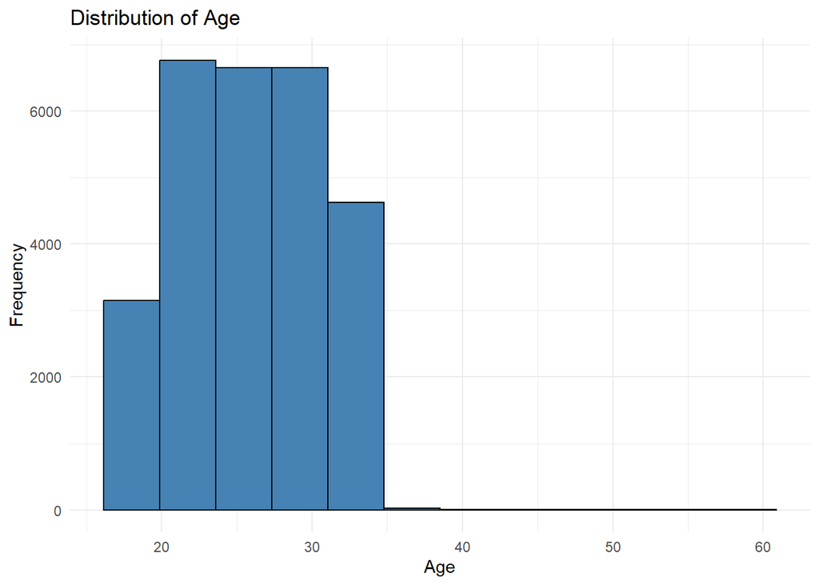

```r
ggplot(
  depression,
  aes(x = Age)
) +
  geom_histogram(
    bins = 12,
    fill = "steelblue",
    color = "black"
  ) +
  labs(
    title = "Distribution of Age",
    x = "Age",
    y = "Frequency"
  ) +
  theme_minimal()
```

### Observation

Most students fall within the typical university age range. The distribution appears slightly right-skewed, indicating fewer older students.

## Distribution of CGPA

CGPA represents academic performance.

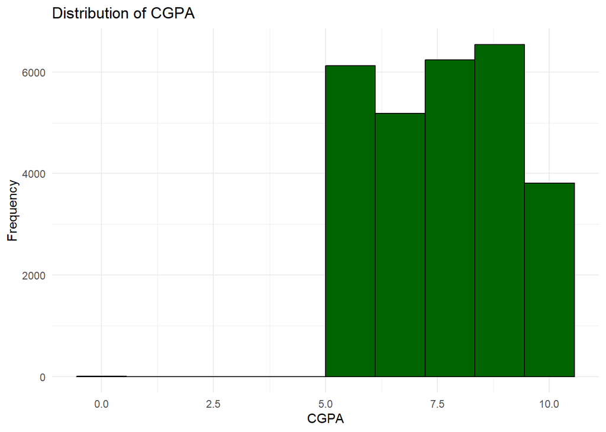

```r
ggplot(
  depression,
  aes(x = CGPA)
) +
  geom_histogram(
    bins = 10,
    fill = "darkgreen",
    color = "black"
  ) +
  labs(
    title = "Distribution of CGPA",
    x = "CGPA",
    y = "Frequency"
  ) +
  theme_minimal()
```

### Observation

Most students have a CGPA concentrated around the middle to higher range, suggesting satisfactory academic performance.

## Distribution of Academic Pressure

Academic pressure measures the level of academic stress experienced by students.

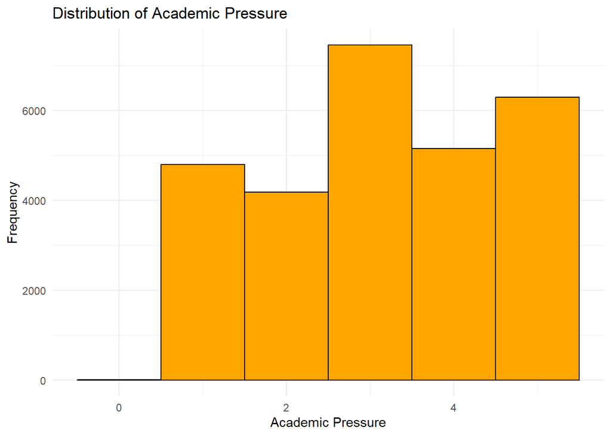

```r
ggplot(
  depression,
  aes(x = `Academic Pressure`)
) +
  geom_histogram(
    binwidth = 1,
    fill = "orange",
    color = "black"
  ) +
  labs(
    title = "Distribution of Academic Pressure",
    x = "Academic Pressure",
    y = "Frequency"
  ) +
  theme_minimal()
```

### Observation

The majority of students report moderate to high academic pressure, indicating academic stress is common.

## Distribution of Financial Stress

Financial stress can significantly affect mental well-being.

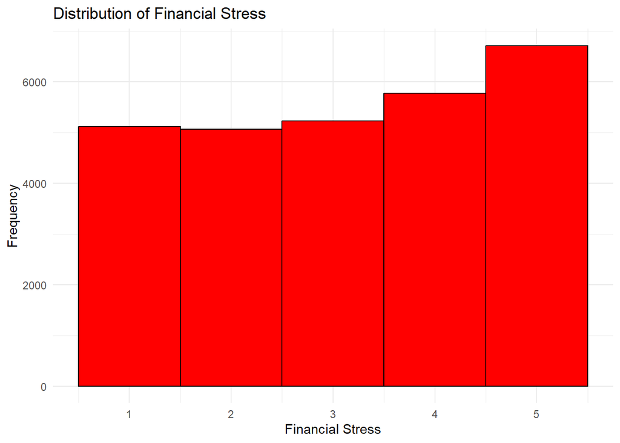

```r
ggplot(
  depression,
  aes(x = `Financial Stress`)
) +
  geom_histogram(
    binwidth = 1,
    fill = "red",
    color = "black"
  ) +
  labs(
    title = "Distribution of Financial Stress",
    x = "Financial Stress",
    y = "Frequency"
  ) +
  theme_minimal()
```

## Skewness Analysis

Skewness quantifies asymmetry in a distribution. Values near 0 indicate symmetry; |skew| > 1 generally signals a transformation (log, sqrt) may improve model performance for algorithms sensitive to distributional shape (e.g. linear/logistic regression).

```r
install.packages("kableExtra")
library(tidyverse)
library(e1071)
library(corrplot)
library(knitr)
library(kableExtra)
numeric_vars <- c("Age", "CGPA", "Academic Pressure", "Work Pressure",
                   "Study Satisfaction", "Job Satisfaction",
                   "Work/Study Hours", "Financial Stress")

skew_table <- tibble(
  Variable = numeric_vars,
  Skewness = sapply(numeric_vars, function(v) round(skewness(depression[[v]], na.rm = TRUE), 3))
) %>%
  mutate(
    Interpretation = case_when(
      abs(Skewness) < 0.5 ~ "Approximately symmetric — no transformation needed",
      abs(Skewness) < 1   ~ "Moderately skewed — transformation optional",
      TRUE                ~ "Highly skewed — transformation recommended"
    )
  )

kable(skew_table, caption = "Table 3.1: Skewness of Numeric Variables") %>%
  kable_styling(bootstrap_options = c("striped", "hover", "condensed"), full_width = FALSE)
```

Table 3.1: Skewness of Numeric Variables

| Variable | Skewness | Interpretation |
| --- | --- | --- |
| Age | 0.132 | Approximately symmetric — no transformation needed |
| CGPA | -0.113 | Approximately symmetric — no transformation needed |
| Academic Pressure | -0.135 | Approximately symmetric — no transformation needed |
| Work Pressure | 108.583 | Highly skewed — transformation recommended |
| Study Satisfaction | 0.010 | Approximately symmetric — no transformation needed |
| Job Satisfaction | 74.098 | Highly skewed — transformation recommended |
| Work/Study Hours | -0.455 | Approximately symmetric — no transformation needed |
| Financial Stress | -0.130 | Approximately symmetric — no transformation needed |